# Exercise RMrkdown and reproductibility course

The EDB RMarkdown superstar learning team

01/03/2022

# 1 Introduction

This exercise is the best way to practice `RMarkdown` (Salinas 2020) now that you have had an overview of how it works. The principle is that you want to produce a copy of this `pdf` file. We provide most of the `R code`, because the scope is to work on the `RMarkdown` (Xie, Allaire, and Grolemund 2018) integration, not on the `R code`.

# 2 Starters

You want to create a new `Rmarkdown` file and save it in the `Exercise` folder.

# 3 Load packages

What packages will I need? Well I can fill that in later anyway.

BTW: To add a new code chunck the keyboard shortcut is `Ctrl` + `Alt` + `i`. Or use the insert button on the top left side of this window.

# 4 Research compendium

Let’s organize our project. We create a folder called `data` and list the files in the current working folder.

```r
system("mkdir -p data")
```

```
## [1] 0
```

```r
list.files(path = ".")
```

```
## [1] "bibliography.bib" "data"             "Exercise.html"    "Exercise.Rmd"
```

```r
list.dirs(path = ".", full.names = TRUE, recursive = TRUE)
```

```
## [1] "."      "./data"
```

We can now move the `datasets.xls` file (main folder to the `Exercise/data` folder).

# 5 Load the project data

We’ll use the mtcars dataset that we"ll load from the `datasets.xls` file. He we do not provide the code because it is part of the exercise.

# 6 Analyze the data

## 6.1 Get a look at the data

```r
#summary(my_mtcars)
my_mtcars2 <- within(my_mtcars, {
   vs <- factor(vs, labels = c("V", "S"))
   am <- factor(am, labels = c("automatic", "manual"))
   cyl  <- ordered(cyl)
   gear <- ordered(gear)
   carb <- ordered(carb)
})
summary(my_mtcars2)
```

```
##       mpg        cyl         disp             hp             drat
##  Min.   :10.40   4:11   Min.   : 71.1   Min.   : 52.0   Min.   :2.760
##  1st Qu.:15.43   6: 7   1st Qu.:120.8   1st Qu.: 96.5   1st Qu.:3.080
##  Median :19.20   8:14   Median :196.3   Median :123.0   Median :3.695
##  Mean   :20.09          Mean   :230.7   Mean   :146.7   Mean   :3.597
##  3rd Qu.:22.80          3rd Qu.:326.0   3rd Qu.:180.0   3rd Qu.:3.920
##  Max.   :33.90          Max.   :472.0   Max.   :335.0   Max.   :4.930
##        wt             qsec       vs             am     gear   carb
##  Min.   :1.513   Min.   :14.50   V:18   automatic:19   3:15   1: 7
##  1st Qu.:2.581   1st Qu.:16.89   S:14   manual   :13   4:12   2:10
##  Median :3.325   Median :17.71                         5: 5   3: 3
##  Mean   :3.217   Mean   :17.85                                4:10
##  3rd Qu.:3.610   3rd Qu.:18.90                                6: 1
##  Max.   :5.424   Max.   :22.90                                8: 1
```

## 6.2 First analysis, fuel consumtion.

I want to assess the motors consumption as a function of the displacement. Engine displacement is the measure of the cylinder volume swept by all of the pistons of a piston engine, excluding the combustion chambers.

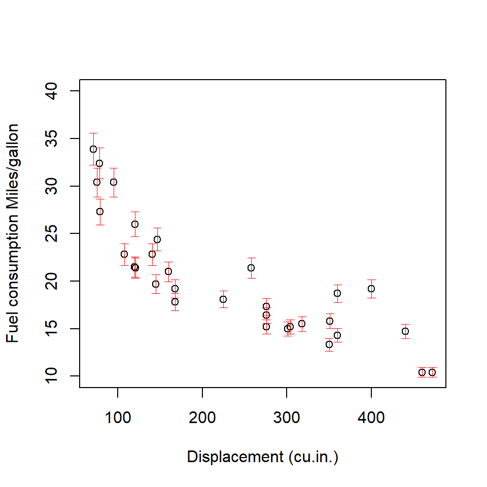

```r
plot(mpg ~ disp, data = my_mtcars,xlab="Displacement (cu.in.)",ylab="Fuel consumption Miles/gallon", ylim=c(10,40))
arrows(x0 = my_mtcars$disp, y0 = my_mtcars$mpg * 0.95, x1 = my_mtcars$disp, y1 = my_mtcars$mpg *
    1.05, angle = 90, code = 3, length = 0.04, lwd = 0.4, col="red")
```

Whoo, that was **interesting**. Can we concldude that biggers motors consume more fuel?

Let’s move on to the next analysis.

## 6.3 Second analysis, is that all?

To assess whether other variables could also explain the consumption I will plot the correlation among each pair of variables in my data.

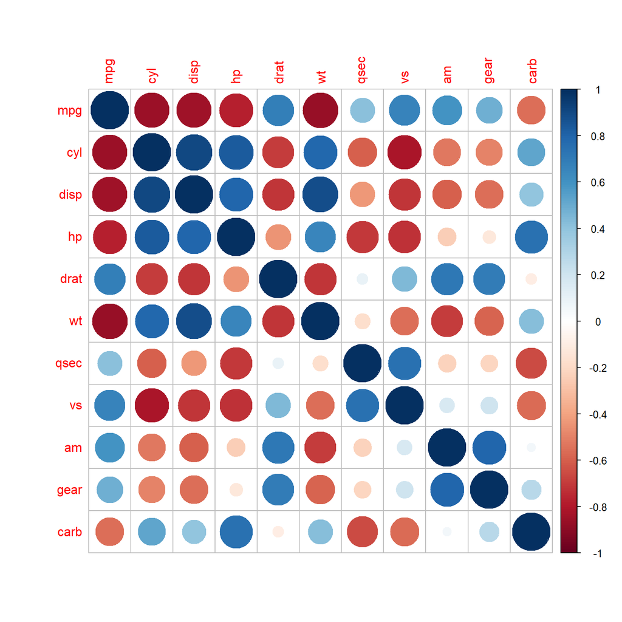

```r
mcor <- cor(my_mtcars)
corrplot(mcor)
```

Whoohoohooo, that plot looks great!

It looks like the **number of cylinders** (cyl), **Gross horsepower** (hp) and the **Weight** (wt. 1000 lbs), could play a role too.

If you are looking for the the variables meaning, you can find it [here](https://www.rdocumentation.org/packages/datasets/versions/3.6.2/topics/mtcars)

## 6.4 Third analysis, we like camembert, they like pie!

Lets produce a pie chart showing the proportion of cars that have different carb values.

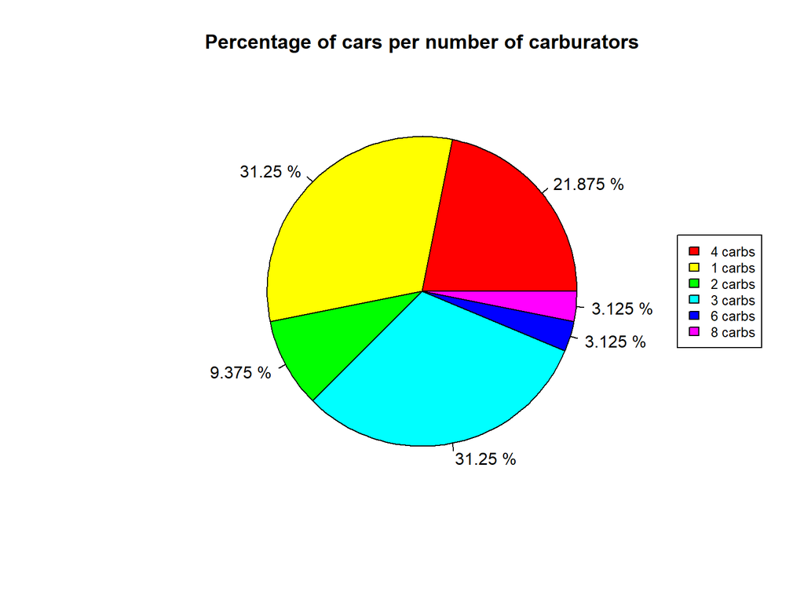

Figure 1: have you ever tried the camenbert pie

```r
#concat the names for the legend
names = as.factor(paste(unique(my_mtcars$carb),"carbs"))
#get the percentages
percent=100*table(my_mtcars$carb)/length(my_mtcars$carb)
pie(x=percent, label=paste(percent, "%"),  col=rainbow(length(names)), main="Percentage of cars per number of carburators" )
#add legend
legend("right",legend = names, fill = rainbow(length(names)), cex=0.8)
```

# 7 Let’s make sure that my figures have been saved!

```r
list.dirs(path = ".", full.names = TRUE, recursive = TRUE)
```

```
## [1] "."                            "./data"
## [3] "./Exercise_files"             "./Exercise_files/figure-html"
```

```r
list.files(path = "./Exercise_files/figure-html/")
```

```
## [1] "ho_mae-1.png"    "mpg_disp-1.png"  "mtcorplot-1.png"
```

# 8 Print a nice table of….

```r
table(my_mtcars2$gear,my_mtcars2$carb)
```

```
##
##     1 2 3 4 6 8
##   3 3 4 3 5 0 0
##   4 4 4 0 4 0 0
##   5 0 2 0 1 1 1
```

# Bibliography

Salinas, Isaac Quintanilla. 2020. “R Markdown Guide.”

Xie, Yihui, Joseph J Allaire, and Garrett Grolemund. 2018. *R Markdown: The Definitive Guide*. Chapman; Hall/CRC.